# TEST_Deloitte

## Question 1

A water supply company asks Deloitte for an analysis that allows senior management to understand the internal and external factors that affect water demand in their catchment area, as well as to make a forecast of such demand for the following two years. Therefore, your Manager asks you to develop a descriptive and predictive analysis of water demand by region based on historical data and external variables.

In the Excel find attached you will find a data set that contains data related to the water demand/consumption (i.e. cubic meters), price, weather and client characteristics (i.e. number of households and companies). With this data, perform the tasks that your Manager requested and explain the methodology chosen and results briefly. In addition, we encourage you to make any comments related to the data set provided (e.g. limitations, missing variables, etc.)

```python
import numpy as np
import pandas as pd
import seaborn as sns

import warnings
warnings.simplefilter(action='ignore', category=FutureWarning)
```

```python
# Needs openpyxl lib
data_path = 'DTT_Data_Scientist_Test.xlsx'
database = pd.read_excel(data_path)
database.head()
```

|  | Zona | Fecha | MC | Clientes | Precio_Medio | Precipitacion | Temperatura | Poblacion | Desempleo | Renta | ... | Empresas_Construccion | Empresas_CTH | Empresas_Servicios | Hogar_Total | Hogar_1pax | Hogar_2pax | Hogar_3pax | Hogar_4pax | Hogar_5pax | Hogar_6pax |
| --- | --- | --- | --- | --- | --- | --- | --- | --- | --- | --- | --- | --- | --- | --- | --- | --- | --- | --- | --- | --- | --- |
| 0 | A | 2019 1Q | 531930.18 | 16650.12 | 1.701437 | 1.755423 | 9.952688 | 41281.8 | 2863.35 | 6158.25000 | ... | 339 | 1110 | 1691 | 16041 | 4381 | 4634 | 3200 | 3012 | 597 | 217 |
| 1 | A | 2019 2Q | 557170.62 | 16658.13 | 1.689908 | 0.790385 | 20.306114 | 41281.8 | 2641.80 | 6158.25000 | ... | 339 | 1110 | 1691 | 16051 | 4384 | 4637 | 3202 | 3014 | 597 | 217 |
| 2 | A | 2019 3Q | 569989.20 | 16735.56 | 1.645398 | 0.537554 | 25.323083 | 41281.8 | 2592.45 | 6158.25000 | ... | 339 | 1110 | 1691 | 16143 | 4409 | 4663 | 3221 | 3031 | 601 | 218 |
| 3 | A | 2019 4Q | 556886.13 | 16743.57 | 1.700518 | 0.862167 | 11.566897 | 41281.8 | 2636.55 | 6158.25000 | ... | 339 | 1110 | 1691 | 16151 | 4411 | 4666 | 3222 | 3033 | 601 | 218 |
| 4 | A | 2020 1Q | 513545.34 | 16761.37 | 1.740904 | 2.760333 | 8.468011 | 41517.0 | 2638.65 | 6322.05945 | ... | 344 | 1071 | 1750 | 16133 | 4406 | 4660 | 3219 | 3029 | 601 | 218 |

5 rows × 24 columns

```python
database.info()
```

```
<class 'pandas.core.frame.DataFrame'>
RangeIndex: 72 entries, 0 to 71
Data columns (total 24 columns):
 #   Column                 Non-Null Count  Dtype
---  ------                 --------------  -----
 0   Zona                   72 non-null     object
 1   Fecha                  72 non-null     object
 2   MC                     72 non-null     float64
 3   Clientes               72 non-null     float64
 4   Precio_Medio           72 non-null     float64
 5   Precipitacion          72 non-null     float64
 6   Temperatura            72 non-null     float64
 7   Poblacion              72 non-null     float64
 8   Desempleo              72 non-null     float64
 9   Renta                  72 non-null     float64
```

[output cut: 16 more lines]

**Semantic Interpretation** The following description also shows interesting questions about possible mistakes that must be treated.

1. Zona: geographic region.
2. Fecha: year and trimester (1Q: Jan,Feb,Mar; 2Q:Apr,May,Jun, etc.)
3. MC: amount of demand (cubic meters)
4. Clientes: number of clients. (**Why is not an Integer?**)
5. Precio_Medio: mean price for each MC.
6. Precipitacion: meteorology measurement related to rain, humidity, etc. (**No information about the metric unit, or if it is an average for the period or just an accumulative quantity**)
7. Temperature: average wether
8. Poblacion: Population (**why is not an integer**)
9. Desempleo: Unemployment (**why is not an integer**).
10. Renta: average housing price.
11. Densidad: population density
12. Edad_Media: average age of the population
13. Empresas_Total: total number of companies in the zone
14. Empresas*x: total number of specific type of company ($\Sigma*{x} Empresas*x =^? Empresas*{Total}$)
18. Hogar_Total: total number of homes.
19. Hogar*x: total number of home for a given type (1, 2,...,6 habitants)($\Sigma*{x} Hogar*x =^? Hogar*{Total}$)

```python
# Row sample
database.iloc[0]
```

```
Zona                             A
Fecha                      2019 1Q
MC                       531930.18
Clientes                  16650.12
Precio_Medio              1.701437
Precipitacion             1.755423
Temperatura               9.952688
Poblacion                  41281.8
Desempleo                  2863.35
Renta                      6158.25
Densidad                  2.206639
Edad_Media               43.965158
Empresas_Total                3603
Empresas_Industria             463
Empresas_Construccion          339
Empresas_CTH                  1110
Empresas_Servicios            1691
Hogar_Total                  16041
Hogar_1pax                    4381
Hogar_2pax                    4634
Hogar_3pax                    3200
Hogar_4pax                    3012
Hogar_5pax                     597
Hogar_6pax                     217
Name: 0, dtype: object
```

##### Checking and Cleaning

```python
features_zero = []
for c in database.columns:
    if not database[database[c]== 0].all().all():
        features_zero.append(c)
features_zero
```

```
['Empresas_Total',
 'Empresas_Industria',
 'Empresas_Construccion',
 'Empresas_CTH',
 'Empresas_Servicios',
 'Hogar_6pax']
```

*Are these zero-values a real quantity? or Are they missed values?*

Checking the original table, we can find a `-` character. I think it refers a 'no information'.

Also these missings are correlated with the geographic zone (`Zona`):

```python
for c in features_zero:
    print(set(database[database[c]== 0]['Zona']))
```

```
{'E'}
{'E'}
{'E'}
{'E'}
{'E'}
{'C', 'F'}
```

- the zone `E` has not information about Companies (`Empresas_*`) and
- The zones `C`, `F` have no information about Homes 6pax Homes (`Hogar_6pax`).

One possible interpretation is as follow:

```
* It is not very common to find a zone without any company (industrial, services, comercial, etc)
* It could be possible to find zones with no 6pax homes (for example, neighborhoods with small apartments)
```

This interpretation suggest the `0-values` as a missing for the feature `Empresas_*` but 0 for `Hogar_6pax`.

However, we will need to analyze it better. For example, comparing the energy demand of the zone.

```python
if database.isnull().any().sum() == 0:
    print('Not null values.')
else:
    print('Missed values found.')
```

```
Not null values.
```

*Lets check the sumatory of the different features respect to its sub-type.*

```python
sum_ = database[['Empresas_Industria', 'Empresas_Construccion', 'Empresas_CTH', 'Empresas_Servicios']].sum(axis=1)
(database['Empresas_Total'] == sum_).all()
```

```
True
```

```python
sum_ = database[['Hogar_1pax', 'Hogar_2pax', 'Hogar_3pax', 'Hogar_4pax', 'Hogar_5pax', 'Hogar_6pax']].sum(axis=1)
(database['Hogar_Total'] == sum_).all()
```

```
True
```

*Rounding and Casting continuous to discrete*

```python
#database['Poblacion'] = database['Poblacion'].astype(int)  # Truncate.
database['Poblacion'] = database['Poblacion'].round(0).astype(int)  #Rounding
database['Desempleo'] = database['Desempleo'].round(0).astype(int)
database['Clientes'] = database['Clientes'].round(0).astype(int)
```

```python
# Seasonal dates (yyyy{1,2,3,4}Q)
def fiscal_format(s):
    y,q= s.split()
    return ''.join([y, q[1], q[0]])

database['Fecha']= database['Fecha'].apply(lambda r: fiscal_format(r)) \
                                    .apply(lambda r: pd.Period(r, freq='Q'))
```

```python
database['Fecha']
```

```
0     2019Q1
1     2019Q2
2     2019Q3
3     2019Q4
4     2020Q1
       ...
67    2020Q4
68    2021Q1
69    2021Q2
70    2021Q3
71    2021Q4
Name: Fecha, Length: 72, dtype: period[Q-DEC]
```

```python
database.info()
```

```
<class 'pandas.core.frame.DataFrame'>
RangeIndex: 72 entries, 0 to 71
Data columns (total 24 columns):
 #   Column                 Non-Null Count  Dtype
---  ------                 --------------  -----
 0   Zona                   72 non-null     object
 1   Fecha                  72 non-null     period[Q-DEC]
 2   MC                     72 non-null     float64
 3   Clientes               72 non-null     int64
 4   Precio_Medio           72 non-null     float64
 5   Precipitacion          72 non-null     float64
 6   Temperatura            72 non-null     float64
 7   Poblacion              72 non-null     int64
 8   Desempleo              72 non-null     int64
 9   Renta                  72 non-null     float64
```

[output cut: 16 more lines]

*Correlation by Zones.*

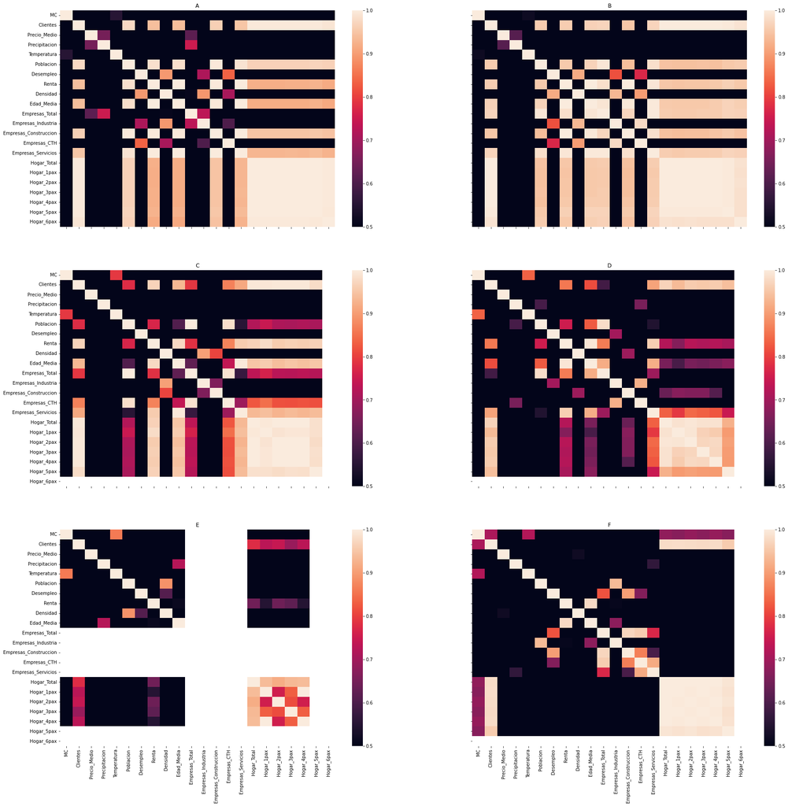

```python
from matplotlib import pyplot as plt

fig,axn = plt.subplots(3, 2, sharex=True, sharey=True)

fig.set_figheight(30)
fig.set_figwidth(30)


zones = database['Zona'].unique()
for i, ax in enumerate(axn.flat):
    ax.set_title(zones[i])
    sns.heatmap(database[(database['Zona']==zones[i])].corr(),
                vmin=.5,
                xticklabels=True, yticklabels=True,
                ax=ax);
```

There are some clear correlations between population, density, houses, etc. As a first view, it seems difficult to find a quick relationship between the companies (`Empresas_*`) and the other variables.

There are some possibilities to fill these values:

- Perform a supervised approach, using all the variables as a input and `Empresas_*` as a target to predict them for Zone E could be interesting. But with a higher cost than a MC prediction (?)
- Fill the variables with zero, assuming is not a missing and considering they refer just a small residential zone.
- The supervised approach must be simple and fast. Doing this, it is likely to obtain some similar values than the mean or median.
- Which is the general distribution of these features?
- Which is the relationship of these features with respect to population/density/MC?

*Descriptive information by Zone*

```python
def feature_by_zone(feature, database, remove=''):
    zones = list(database['Zona'].unique())
    if remove:
        zones.remove(remove)
    df = {}
    for z in zones:
        df[z] = database[(database['Zona']==z)].sort_values(by='Fecha')[feature].values

    return pd.DataFrame(df)

df = feature_by_zone('Empresas_Total', database, 'E')
total_mean = df.mean()
df.describe()
```

|  | A | B | C | D | F |
| --- | --- | --- | --- | --- | --- |
| count | 12.000000 | 12.000000 | 12.000000 | 12.000000 | 12.000000 |
| mean | 3613.000000 | 628.666667 | 317.333333 | 209.333333 | 209.000000 |
| std | 21.759011 | 10.421423 | 2.741378 | 2.461830 | 6.149649 |
| min | 3594.000000 | 618.000000 | 315.000000 | 206.000000 | 201.000000 |
| 25% | 3594.000000 | 618.000000 | 315.000000 | 206.000000 | 201.000000 |
| 50% | 3603.000000 | 626.000000 | 316.000000 | 211.000000 | 211.000000 |
| 75% | 3642.000000 | 642.000000 | 321.000000 | 211.000000 | 215.000000 |
| max | 3642.000000 | 642.000000 | 321.000000 | 211.000000 | 215.000000 |

```python
df = {}
for feat in ['Empresas_Industria', 'Empresas_Construccion', 'Empresas_CTH', 'Empresas_Servicios']:
    df[feat] = feature_by_zone(feat, database, 'E').mean()

pd.DataFrame(df)
```

|  | Empresas_Industria | Empresas_Construccion | Empresas_CTH | Empresas_Servicios |
| --- | --- | --- | --- | --- |
| A | 436.000000 | 344.666667 | 1079.666667 | 1752.666667 |
| B | 58.000000 | 136.333333 | 226.000000 | 208.333333 |
| C | 46.666667 | 40.666667 | 114.333333 | 115.666667 |
| D | 22.000000 | 42.000000 | 62.333333 | 83.000000 |
| F | 57.000000 | 33.000000 | 52.333333 | 66.666667 |

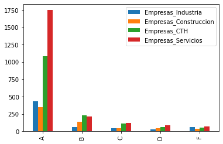

```python
pd.DataFrame(df).plot(kind='bar');
```

```python
pd.DataFrame(df).mean()
```

```
Empresas_Industria       123.933333
Empresas_Construccion    119.333333
Empresas_CTH             306.933333
Empresas_Servicios       445.266667
dtype: float64
```

Using the mean could bias the number of Empresas considering the zone A as an outlier. If the region E and A have similar characteristics could be a good option (we will check this).

For simplicity, we could use the mean without consideration of the outlier-Zone to see how it looks.

```python
imputation = pd.DataFrame(df).loc[['B', 'C', 'D', 'F']].mean()
imputation
```

```
Empresas_Industria        45.916667
Empresas_Construccion     63.000000
Empresas_CTH             113.750000
Empresas_Servicios       118.416667
dtype: float64
```

```python
# Copy for checking. I will chekc naother information before to decide if I use this imputaion or not.
database_imputed = database.copy()

for feat in imputation.index:
    row_idxs = database_imputed[database['Zona'] == 'E'][feat].index
    col_idxs = database_imputed.columns.get_loc(feat)
    database_imputed.iloc[row_idxs, col_idxs] = imputation.loc[feat].item()
```

```python
row_idxs = database_imputed[database['Zona'] == 'E']['Empresas_Total'].index
col_idxs = database_imputed.columns.get_loc('Empresas_Total')
database_imputed.iloc[row_idxs, col_idxs] = imputation.sum().item()
```

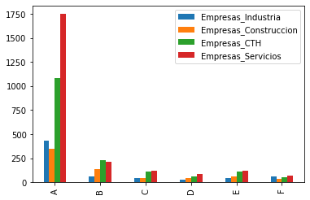

```python
df = {}
for feat in ['Empresas_Industria', 'Empresas_Construccion', 'Empresas_CTH', 'Empresas_Servicios']:
    df[feat] = feature_by_zone(feat, database_imputed, '').mean()

pd.DataFrame(df).plot(kind='bar');
```

This plot shows how the `Empresas_*` variables looks after the mean imputation with now consideration of the Zone A.

This option could be possible but the MC of the zone E is considerabily lower respect to all the others (see bellow).

```python
(database['Clientes'] <= database['Empresas_Total'] + database['Hogar_Total']).all()
```

```
True
```

*Descriptive information by Zone and Period respect to the MC*

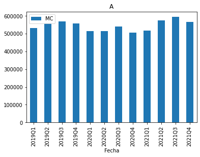

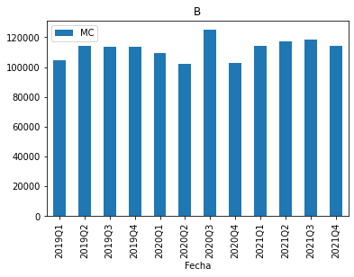

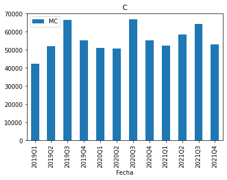

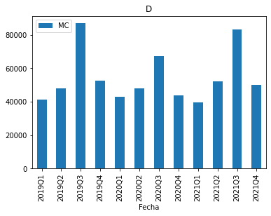

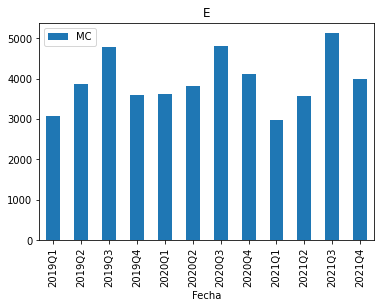

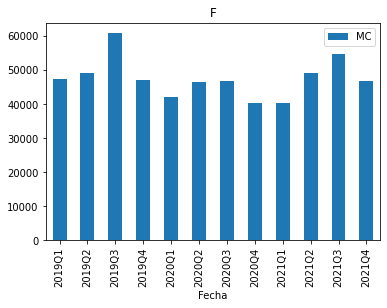

```python
for zona in database['Zona'].unique():
    database[database['Zona']==zona].sort_values(by='Fecha')[['Fecha','MC']].plot(kind='bar', x='Fecha', y='MC', title=zona)
```

*Descriptive information by Zone and respect to the demand by client (MC/Client)*

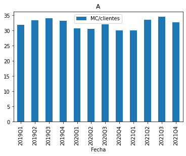

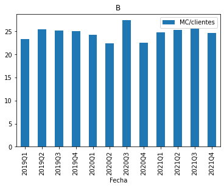

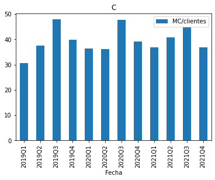

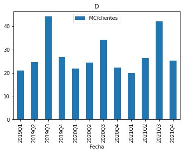

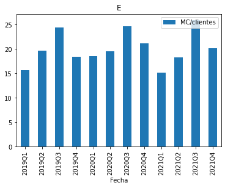

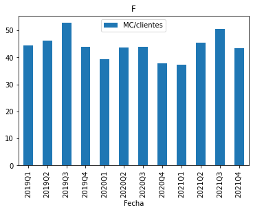

```python
mc_clientes = database[['Zona', 'Fecha', 'MC', 'Clientes']]
mc_clientes['MC/clientes'] = mc_clientes['MC'] / mc_clientes['Clientes']

for zona in mc_clientes['Zona'].unique():
    mc_clientes[mc_clientes['Zona']==zona].sort_values(by='Fecha').plot(kind='bar', x='Fecha', y='MC/clientes', title=zona)
```

- Similar **trends** when we perform a correction with the number of clients (Ups and Downs in similar seasons).
- Then, similar peaks in similar seasons (correlation between the season and the demand(MC))
- Different variability of demand with respect to the zones: A, B shows more uniform demand than the others (more predictable?)
- Beyond the total MC demand, there are interesting views when correcting by number of clients. For example, Zone B shows less per-client demand than other zones like F. ¿Is there any particular client that biases the total demand?

*Period of demand and Zones: relative plot*

```python
zones, periods, avgs = [], [], []
for zona in database['Zona'].unique():
    for q in [1,2,3,4]:
            zone_df = database[database['Zona']==zona]
            period_idx = (zone_df['Fecha'].apply(lambda r: r.quarter) == q)

            zones.append(zona)
            periods.append(q)
            avgs.append(zone_df[period_idx]['MC'].mean().item())

MC_period = pd.DataFrame({'zone': zones,
                         'period': periods,
                         'avg': avgs})
```

```
Relationship between each zone and their average demand per season.
```

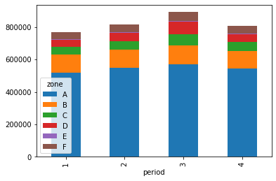

```python
MC_period.sort_values(by='avg').pivot_table(index=['period'], columns='zone', values='avg').plot(kind='bar', stacked=True);
print('Relationship between each zone and their average demand per season.')
```

The most important information is that the Zone E has a very low demand respect to all the other zones.

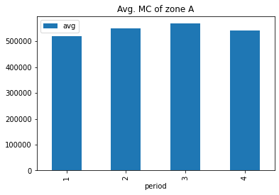

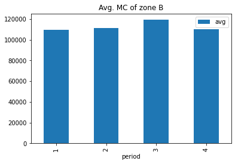

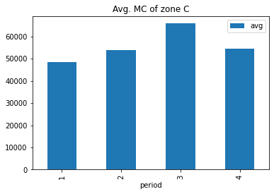

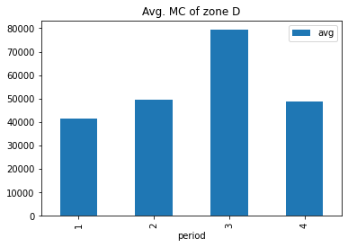

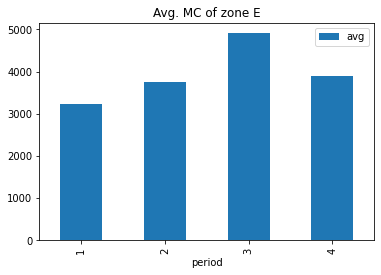

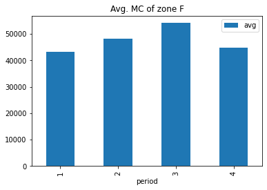

```python
for zona in database['Zona'].unique():
    MC_period[MC_period['zone'] == zona].plot(kind='bar', x='period', y='avg', title='Avg. MC of zone '+zona)
```

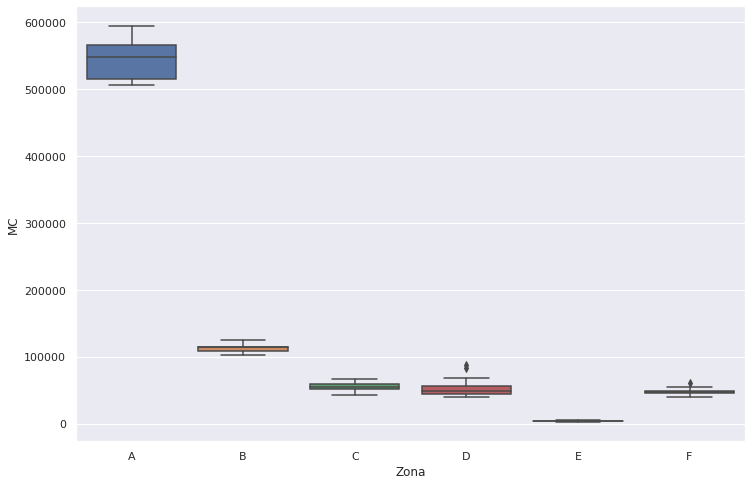

```python
import seaborn as sns

sns.set(rc={'figure.figsize':(12,8)})
sns.boxplot(data=mc_clientes, x='Zona', y='MC');
```

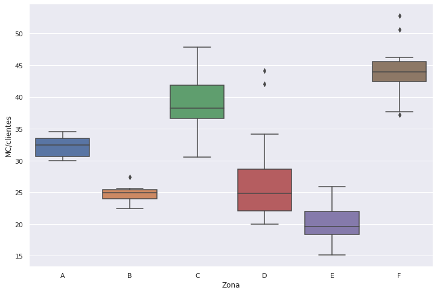

```python
sns.boxplot(data=mc_clientes, x='Zona', y='MC/clientes')
```

The relationship between the distribution of the different zones changes abruptly when we analyze the demand by clients. As we noticed previously, there are big differences when we consider the total demand than considering the average demand by clients.

*Variational ratio of demand*

```python
variation = {}
for zona in mc_clientes['Zona'].unique():
    z = mc_clientes[mc_clientes['Zona']==zona][['MC']].values
    variation[zona] = z.std() / z.mean()

pd.DataFrame(variation, index=[0])
```

|  | A | B | C | D | E | F |
| --- | --- | --- | --- | --- | --- | --- |
| 0 | 0.050699 | 0.057708 | 0.12492 | 0.27959 | 0.162567 | 0.116275 |

We can confirm a lesser variation in A and B. Also, a huge variability in zone D. Notice that in D (and F) exist outliers that could bias this information.

The previous analysis is to obtain a first insight about the data. We are checking the demand with respect to the time season and the Zone and the number of clients as principal variables.

```python
database[['MC', 'Clientes']].corr()
```

|  | MC | Clientes |
| --- | --- | --- |
| MC | 1.000000 | 0.994064 |
| Clientes | 0.994064 | 1.000000 |

```python
empresas = ['Empresas_Total', 'Empresas_Industria', 'Empresas_Construccion', 'Empresas_CTH', 'Empresas_Servicios']
database[['MC'] + empresas].corr()
```

|  | MC | Empresas_Total | Empresas_Industria | Empresas_Construccion | Empresas_CTH | Empresas_Servicios |
| --- | --- | --- | --- | --- | --- | --- |
| MC | 1.000000 | 0.996356 | 0.978583 | 0.976667 | 0.995636 | 0.994312 |
| Empresas_Total | 0.996356 | 1.000000 | 0.987160 | 0.975027 | 0.998686 | 0.998073 |
| Empresas_Industria | 0.978583 | 0.987160 | 1.000000 | 0.946625 | 0.984292 | 0.982985 |
| Empresas_Construccion | 0.976667 | 0.975027 | 0.946625 | 1.000000 | 0.980503 | 0.963621 |
| Empresas_CTH | 0.995636 | 0.998686 | 0.984292 | 0.980503 | 1.000000 | 0.994283 |
| Empresas_Servicios | 0.994312 | 0.998073 | 0.982985 | 0.963621 | 0.994283 | 1.000000 |

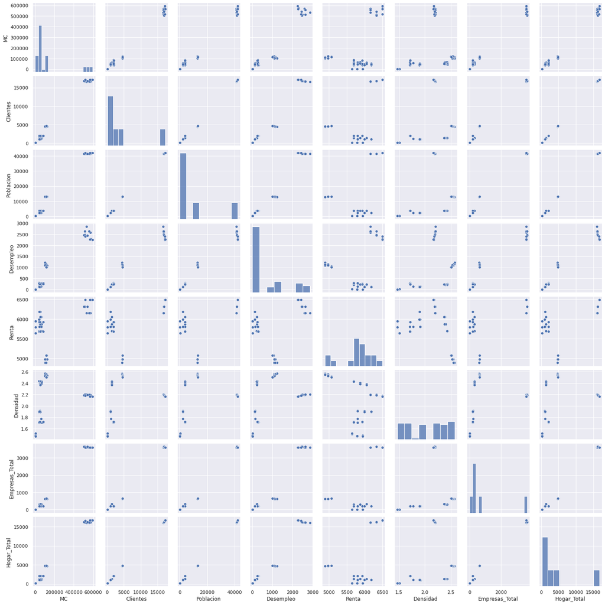

```python
sns.pairplot(database[['MC', 'Clientes', 'Poblacion', 'Desempleo', 'Renta', 'Densidad', 'Empresas_Total', 'Hogar_Total']]);
```

It is possible to find a positive correlation between Empresas, Hogares, Poblacion and Clientes. Which is something expectable.

Another observation is that there exists an interesting relationship with respect to rent (Renta) and the number of clients/companies/homes/population/unemployment. Rent has a similar scatter distribution with respect to all these variables. Which is also expectable given the strong correlation.

This could suggest that it is not needed to use all the variables related to population/homes/etc.

Lets see the clusters respect to the rent:

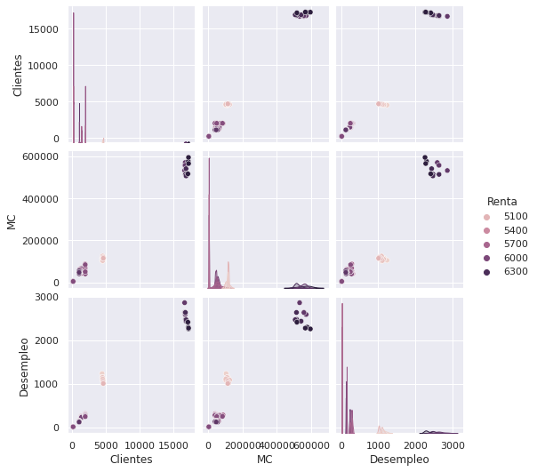

```python
sns.pairplot(database[['Clientes', 'MC', 'Desempleo', 'Renta']],
             hue='Renta');
```

There are similar relationships in terms of high rent and high consumption. Generally speaking it is possible to clusterize by rent. The only one relationship that I would like to discuss is Desempleo. I would like to understand better why high unemployment also has higher values in other variables.

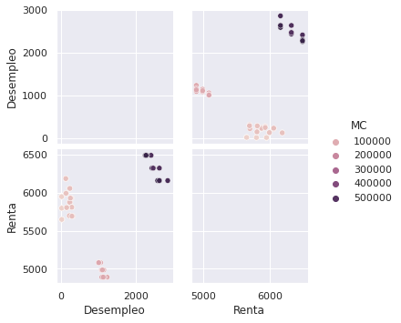

```python
sns.pairplot(database[['Desempleo', 'Renta', 'MC']],
             hue='MC');
```

It shows that the population with high rent and with no job have higher consumption than others. Notice that it is possible to linearly separate the higher consumers.

This plot suggests that there exists a small part of the unemployed population with a high rent and high energy consumption. Also, the unemployed population with middle rent shows less consumption than the rest.

Let's check more variables with respect some of the previous (considering the correlation):

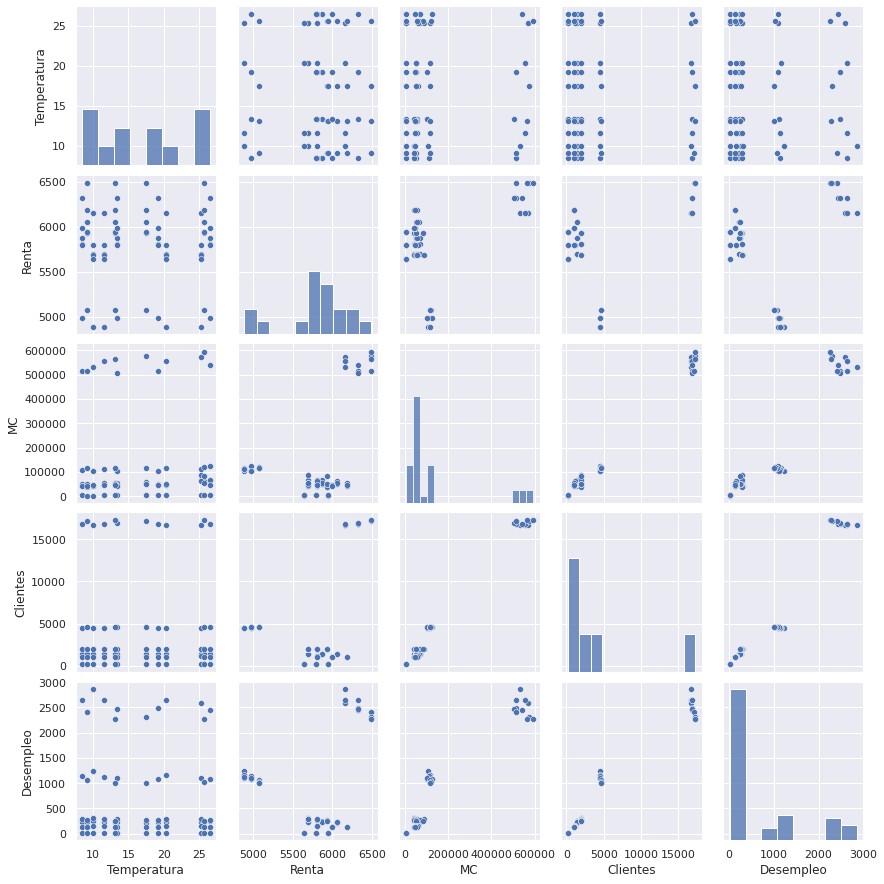

```python
sns.pairplot(database[['Temperatura', 'Renta', 'MC', 'Clientes', 'Desempleo']]);
```

I think these sets of variables could be more discriminative.

However, the number of entries is not very big. SSo we can try to use all the features. After that, with more time, we can see which is the impact of eliminating the correlated variables.

Finding a costless effort in annotation.

Moreover, it could be also compared with the use of a PCA. To see which variables are less or more informative.

**MODEL**

```python
X = database[['Zona', 'Fecha', 'MC']].sort_values(by='Fecha')
X
```

|  | Zona | Fecha | MC |
| --- | --- | --- | --- |
| 0 | A | 2019Q1 | 531930.18 |
| 36 | D | 2019Q1 | 41342.40 |
| 12 | B | 2019Q1 | 104350.41 |
| 24 | C | 2019Q1 | 42221.10 |
| 60 | F | 2019Q1 | 47309.73 |
| ... | ... | ... | ... |
| 47 | D | 2021Q4 | 49924.95 |
| 23 | B | 2021Q4 | 114164.01 |
| 11 | A | 2021Q4 | 565079.79 |
| 59 | E | 2021Q4 | 3993.30 |
| 71 | F | 2021Q4 | 46832.97 |

72 rows × 3 columns

As the date variable (Fecha) is in fiscal period format. We need to cast it to a numeric type. It is possible to make a total integer order from 1 to the length of the data frame. But it is not the best option in case we want to upgrade the dataframe with new intermediate entries.

A better approach could be to use a datetime ordinal converter.

```python
import datetime as dt
X = pd.concat([pd.DataFrame({'Fecha_ord': X['Fecha'] \
                                         .apply(lambda t: t.to_timestamp()) \
                                         .map(dt.datetime.toordinal)}),
               X], axis=1)

X.drop(['Fecha'], axis=1, inplace=True)
X
```

|  | Fecha_ord | Zona | MC |
| --- | --- | --- | --- |
| 0 | 737060 | A | 531930.18 |
| 36 | 737060 | D | 41342.40 |
| 12 | 737060 | B | 104350.41 |
| 24 | 737060 | C | 42221.10 |
| 60 | 737060 | F | 47309.73 |
| ... | ... | ... | ... |
| 47 | 738064 | D | 49924.95 |
| 23 | 738064 | B | 114164.01 |
| 11 | 738064 | A | 565079.79 |
| 59 | 738064 | E | 3993.30 |
| 71 | 738064 | F | 46832.97 |

72 rows × 3 columns

Another observation is that the prediction will be also dependent to the Zone, alternatively we can create one model for each zone. Or to create a double input (time and zone).

I'm considering just these variables as input because I do not have any other information to make the future query. I can create the future dates and also consider all the zones to query but I can not assume any other variable like temperature, density, etc.

Another option could be to take the average of these values as an approximation. But I will need to use the same value at query time. It is not informative.

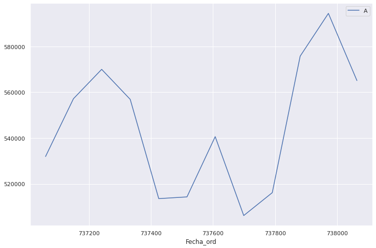

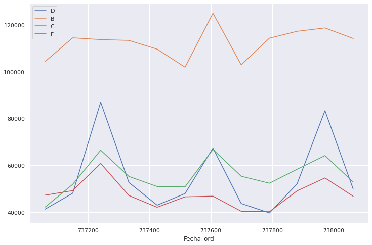

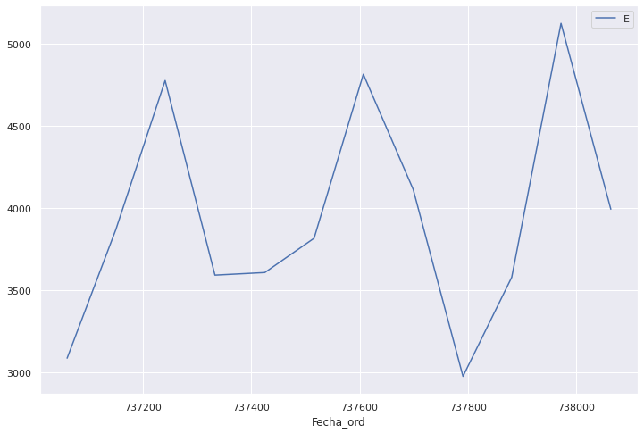

```python
# Each zone as a timeserie plot

z = X['Zona'].unique()[0]
X[X['Zona']==z].plot(x='Fecha_ord', y='MC', label=z);

z = X['Zona'].unique()[1]
ax = X[X['Zona']==z].plot(x='Fecha_ord', y='MC', label=z);
for z in X['Zona'].unique()[2:-1]:
    X[X['Zona']==z].plot(x='Fecha_ord', y='MC', ax=ax, label=z);


z = X['Zona'].unique()[-1]
X[X['Zona']==z].plot(x='Fecha_ord', y='MC', label=z);
```

```python
from sklearn.preprocessing import StandardScaler
from sklearn.linear_model import LinearRegression, Ridge
from sklearn.svm import SVR

from sklearn.pipeline import make_pipeline
from sklearn.preprocessing import StandardScaler
```

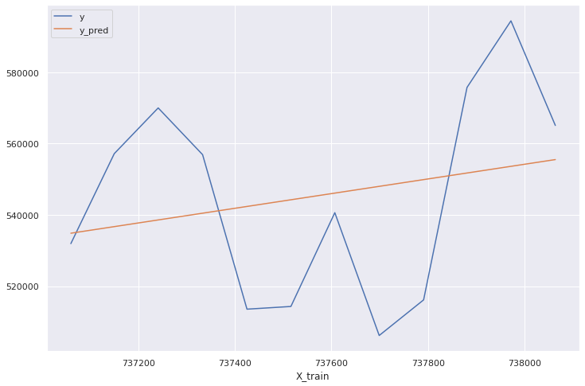

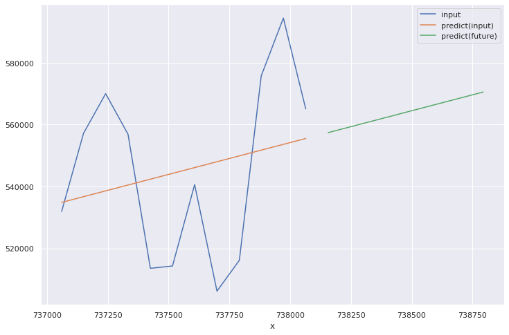

```python
# Linear Regression

z='A'
X_train = X[X['Zona']==z].Fecha_ord.to_numpy().reshape(-1,1)
y = X[X['Zona']==z].MC.to_numpy()


regr = make_pipeline(StandardScaler(),
                    LinearRegression())
regr.fit(X_train, y)
y_pred = regr.predict(X_train)

result = pd.DataFrame({'X_train': X_train.squeeze(), 'y':y, 'y_pred':y_pred})
ax = result.plot(x='X_train', y='y')
result.plot(x='X_train', y='y_pred', ax=ax)


############ Future prediction ############
future = [year+period for year in ['2022', '2023'] for period in ['Q1', 'Q2', 'Q3', 'Q4']]
future_df = pd.DataFrame({'Fecha' : list(map(pd.Period, future))})

future_ord = future_df['Fecha'].apply(lambda t: t.to_timestamp()).map(dt.datetime.toordinal)
future_ord


y_future = regr.predict(future_ord.to_numpy().reshape(-1,1))

result = pd.DataFrame({'X_train': X_train.squeeze(), 'y':y, 'y_pred':y_pred})
ax = result.plot(x='X_train', y='y', label='input')
result.plot(x='X_train', y='y_pred', ax=ax, label='predict(input)')

result = pd.DataFrame({'x': future_ord.to_numpy(),
                     'y': y_future})
result.plot(x='x', y='y', ax=ax, label='predict(future)');
```

In this example we can see the effect of a simple linear regression. The problem with this model is its linearity. As we can see, the prediction will always increase and it is not considering the seasonal cycles.

It could be interesting to try with a nonlinear model but the number of entries for train are low. For example:

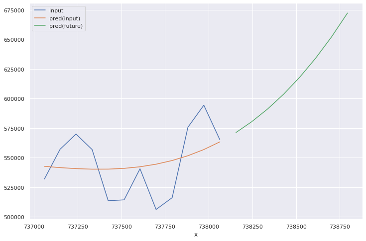

```python
# It is possible to crossvalidate with different hyperparammeters to obtaing a more general function.

z='A'
X_train = X[X['Zona']==z].Fecha_ord.to_numpy().reshape(-1,1)
y = X[X['Zona']==z].MC.to_numpy()


regr = make_pipeline(StandardScaler(),
                    SVR(kernel="poly", C=100, gamma="auto", degree=3, epsilon=0.8, coef0=3))
regr.fit(X_train, y)
y_pred = regr.predict(X_train)

result = pd.DataFrame({'X_train': X_train.squeeze(), 'y':y, 'y_pred':y_pred})
ax = result.plot(x='X_train', y='y', label='input')
result.plot(x='X_train', y='y_pred', label='pred(input)', ax=ax)


y_future = regr.predict(future_ord.to_numpy().reshape(-1,1))
result = pd.DataFrame({'x': future_ord.to_numpy(),
                     'y': y_future})
result.plot(x='x', y='y', ax=ax, label='pred(future)');
```

```python
result = {}
for z in X['Zona'].unique():
    X_train = X[X['Zona']==z].Fecha_ord.to_numpy().reshape(-1,1)
    y = X[X['Zona']==z].MC.to_numpy()


    regr = make_pipeline(StandardScaler(),
                    SVR(kernel="poly", C=100, gamma="auto", degree=2, epsilon=0.8, coef0=3))
    regr.fit(X_train, y)
    y_pred = regr.predict(X_train)
    result[z] = regr.predict(future_ord.to_numpy().reshape(-1,1))

predictions = pd.concat([future_ord, pd.DataFrame(result)], axis=1)
predictions
```

|  | Fecha | A | D | B | C | F | E |
| --- | --- | --- | --- | --- | --- | --- | --- |
| 0 | 738156 | 552648.707794 | 50164.741225 | 115064.455508 | 56078.450763 | 46890.258486 | 3991.926026 |
| 1 | 738246 | 553527.288372 | 50408.971732 | 115252.679194 | 56123.649441 | 46966.744267 | 3980.871625 |
| 2 | 738337 | 554499.161976 | 50666.408567 | 115443.210073 | 56119.317764 | 47065.423193 | 3960.716962 |
| 3 | 738429 | 555567.097591 | 50937.399553 | 115636.055298 | 56063.797192 | 47187.002778 | 3931.164441 |
| 4 | 738521 | 556720.881856 | 51219.174321 | 115829.122329 | 55956.855867 | 47330.517853 | 3892.385399 |
| 5 | 738611 | 557932.653377 | 51505.258236 | 116018.206877 | 55802.483213 | 47492.138420 | 3845.521542 |
| 6 | 738702 | 559241.420047 | 51805.013517 | 116209.608182 | 55596.362744 | 47676.898076 | 3789.159540 |
| 7 | 738794 | 560649.950849 | 52118.787987 | 116403.333399 | 55336.835922 | 47885.504332 | 3723.001798 |

**Conclusion**

I created this predictive model to provide a complete pipeline but it is not suitable for different reasons.

The model is very simple considering we do not have an enough amount of data to create a more complex one.

Another option that could be interesting to explore is the use of all the information provided as input (including the zones with a One-hot encoding). The disadvantage of this approach is that we will need to assume the context of the future. So it is not applicable.

As the amount of data is not big and the linear model suffers monotony, in my opinion, it could be better to use an indicator (avg + std) instead of a time series forecasting approach. Unless we are able to find an extensive history of energy consumption.

A middle-step option is to use a simple model combined with a windows indicator. But, one more time, we need more data.

## Question 2

```python
import openrouteservice as ors
import folium
```

```python
# Names and coordenates for each place of interest
places={'camp_nou': [41.381379, 2.123506],
        'santiago_bernabeu' : [40.453250, -3.688344]}

# Middle point of all the coords. To set the map at the center.
middle_place = np.average(np.array(list(places.values())), axis=0)

map_canvas = folium.Map(location=middle_place, tiles='cartodbpositron', zoom_start=7)

coordinate = list(map(lambda x: list(reversed(x)), places.values()))

ors_key = '' #ADD YOUR OWN KEY
client = ors.Client(key=ors_key)

iso = client.isochrones(
    locations=coordinate,
    range_type='time',
    range=[900, 1800],
    attributes=['area']
)

for isochrone in iso['features']:
    folium.Polygon(locations=[list(reversed(coord)) for coord in isochrone['geometry']['coordinates'][0]],
                  fill_color='blue',
                  stroke=True,
                  color='blue',
                  opacity=0.5).add_to(map_canvas)

for name, coord in places.items():
    folium.Marker(coord, tooltip=name).add_to(map_canvas)

map_canvas
```

Make this Notebook Trusted to load map: File -> Trust Notebook

[interactive chart not shown]

## Question 3

Write a function in Python which takes a vector of length L consisting only of 0s and 1s as input and returns the largest number of consecutive 1s from the vector as an integer.

```python
def count_approach(input_):
    count, i, res = 0, 0, 0

    input_.append(0)  #add extra zero to ensure comparison
                      #in case of max number of 1s at the end. OK, it is not elegant, but actually works.
    while i < len(input_):
        if input_[i] == 1:
            count += 1
        else:
            res = max(res, count)
            count = 0
        i += 1

    return res


# similar but shorter.
def count_approach2(input_):
    count, i, res = 0, 0, 0

    input_.append(0)

    for x in input_:
        count += (x == 1)
        if x == 0:
            res = max(res, count)
            count = 0
    return res


if __name__ == "__main__":
    in1 = [1,1,0,1,1,1,0,0,1]
    in2 = [0,0,0,1,0,0,1,1]
    in3 = [1,1,1,1]
    in4 = [1]

    for input_ in [in1, in2, in3, in4]:
        print(count_approach(input_))
        print(count_approach2(input_))
```

```
3
3
2
2
4
4
1
1
```

## Question 4

#### Understanding the problem (first insights)

In this section, I'll be generating synthetic data to obtain a first insight about the problem.

```python
def generate_uniform_data(ul=100, N=100):
    return [np.random.uniform(0,ul+1) for x in range(N)]

def syn_data_generator(ul, N):
    sql = generate_uniform_data(ul, N)
    code = generate_uniform_data(ul, N)

    data = pd.DataFrame({'sql': sql,
                         'code':code,
                        })
    return data
```

```python
# example of a dataframe with 100 entries (for both sql and code scores).
data = syn_data_generator(ul=100, N=100)

# Filtering the rows with a sum greater than 100.
data_invited = data[data.sum(axis = 1) > 100]
len(data_invited)
```

```
55
```

Which is the average number of invited candidates (sum > 100) considering different amount of candidates (N). Meaning, the convergence of the conditional variable $[U_{code} + U_{sql}]$ when the number of candidates increase.

```python
n_experiments = 10
ul=100
data100 = [syn_data_generator(ul=ul, N=100) for x in range(n_experiments)]
data1000 = [syn_data_generator(ul=ul, N=1000) for x in range(n_experiments)]
data10000 = [syn_data_generator(ul=ul, N=10000) for x in range(n_experiments)]
```

```python
# Intentionaly blank.
```

```python
data_invited100 = [len(data[data.sum(axis = 1) > 100]) for data in data100]
data_invited1000 = [len(data[data.sum(axis = 1) > 100]) for data in data1000]
data_invited10000 = [len(data[data.sum(axis = 1) > 100]) for data in data10000]
```

```python
experiments = pd.DataFrame({'100': data_invited100,
                            '1000': data_invited1000,
                            '10000': data_invited10000,
                           })
experiments.describe()
```

|  | 100 | 1000 | 10000 |
| --- | --- | --- | --- |
| count | 10.000000 | 10.000000 | 10.00000 |
| mean | 51.700000 | 514.800000 | 5095.50000 |
| std | 6.976946 | 10.538817 | 30.67844 |
| min | 40.000000 | 502.000000 | 5046.00000 |
| 25% | 46.500000 | 505.500000 | 5075.75000 |
| 50% | 53.500000 | 513.500000 | 5092.50000 |
| 75% | 55.750000 | 521.750000 | 5116.00000 |
| max | 62.000000 | 534.000000 | 5143.00000 |

The average amount of invited candidates (mean of the variable $[U_{code} + U_{sql}]_{>100}$) converges to $N/2$.

Which means that considering this 'sum score' **we are filtering the half part of the candidates**.

#### Plots and correlation analysis.

```python
def plot_data(data, data_invited):
    ax = data.plot(kind='scatter', x='sql', y='code', s=20, label='SQL + Code');
    data_invited.plot(kind='scatter', x='sql', y='code', c='orange', s=10, label='[SQL + Code] > 100', ax=ax);

    ax = np.log2(data).plot(kind='scatter', x='sql', y='code', s=20, title='log transformation.');
    np.log2(data_invited).plot(kind='scatter', x='sql', y='code', c='orange', s=10, ax=ax);
```

```
           sql      code
sql   1.000000  0.025006
code  0.025006  1.000000
           sql      code
sql   1.000000 -0.484864
code -0.484864  1.000000

------log transformation-------

           sql      code
sql   1.000000  0.025879
code  0.025879  1.000000
           sql      code
sql   1.000000 -0.411208
code -0.411208  1.000000
```

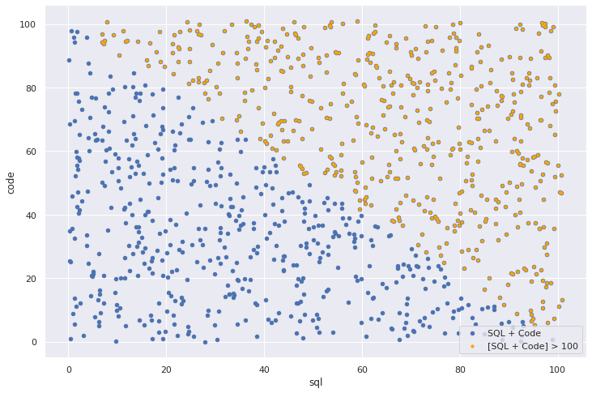

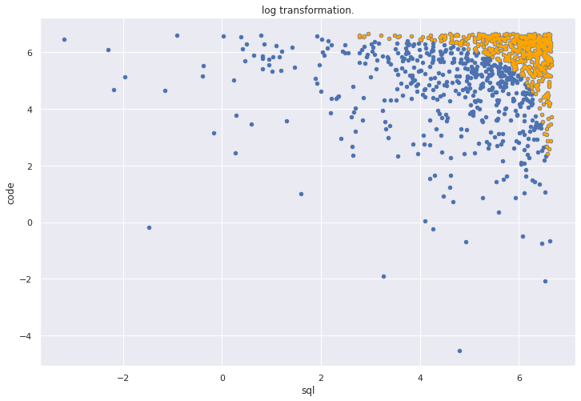

```python
ul = 100
N = 1000

data = syn_data_generator(ul, N)
data_invited = data[data.sum(axis = 1) > ul]

plot_data(data, data_invited)

print(data.corr())
print(data_invited.corr())
print('\n------log transformation-------\n')
print(np.log2(data).corr())
print(np.log2(data_invited).corr())
```

```
           sql      code
sql   1.000000  0.011048
code  0.011048  1.000000
           sql      code
sql   1.000000 -0.484291
code -0.484291  1.000000

------log transformation-------

           sql      code
sql   1.000000  0.005615
code  0.005615  1.000000
           sql      code
sql   1.000000 -0.403904
code -0.403904  1.000000
```

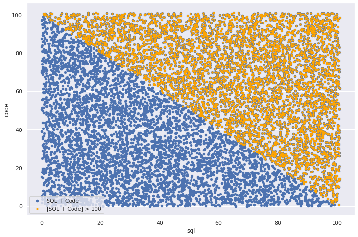

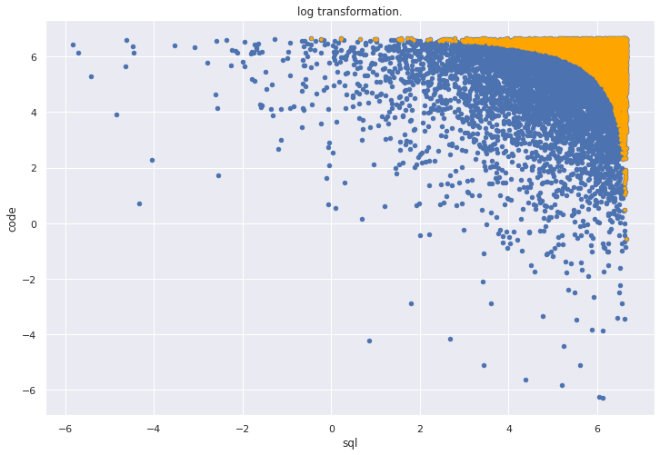

```python
ul = 100
N = 10000
data = syn_data_generator(ul, N)
data_invited = data[data.sum(axis = 1) > ul]
plot_data(data, data_invited)

print(data.corr())
print(data_invited.corr())
print('\n------log transformation-------\n')
print(np.log2(data).corr())
print(np.log2(data_invited).corr())
```

Seeing the plots, I'm not able to confirm there is a correlation between the variables. Checking the Pearson's coefficient, we can find a very low correlation between the $U_{sql}$ and $U_{code}$ variables. But it is possible to notice a higher correlation comparing the variables that sum more than 100.

However, I am not convinced to say that the correlation is strong. Actually, when the number of entries increases the correlation looks lower (it is possible to check when N goes from $10e2$ to $10e3$). Which makes me think that taking a limit when the number of candidates increases the correlation is between $0$ and $0.5$.

It could be needed a more extensive simulation. But as a general answer I can say:

1. There is no correlation between SQL and CODE scores.
2. Considering the conditional sumatory (sql+code > 100) it is possible to find a "middle" or "low" correlation. Meaning, that there exists more correlation than the complete SQL and CODE scores but it is not strong.

For a sanity check, we can simulate different datasets increasing their size (CTL). Then, plot the correlation with respect to the dataset size and see if there is a convergence to 0 and a convergence to +-0.5 in the $sumScore$ and $sumScore>100$ respectively.

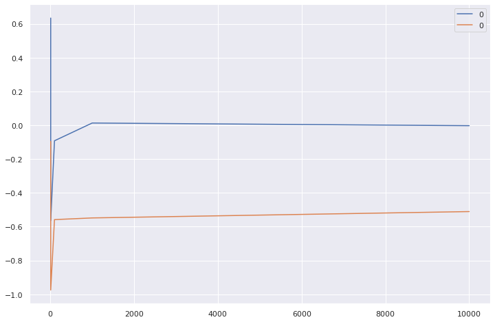

```python
ul = 100
N = [10, 10, 100, 1000, 10000]

data_corrs, data_invited_corrs = [], []
for n in N:
    data = syn_data_generator(ul, n)
    data_invited = data[data.sum(axis = 1) > ul]

    data_corrs.append(data.corr().code.sql)
    data_invited_corrs.append(data_invited.corr().code.sql)

ax = pd.DataFrame(data_corrs, N).plot(label='data correlation');
pd.DataFrame(data_invited_corrs, N).plot(ax=ax, label='data_invited correlation');
```

Finally, we obtained NO CORRELATION for $U_{sql} + U_{code}$ and a middle correlation for $[U_{sql} + U_{code}]_{>100}$

A very important fact is that the previous analysis is more accurate when the number of candidates increases enough. However, It is suitable. In other cases (a few candidates) it is possible to analyze them case by case.

Meaning that the approach could be a good attempt to make a "middle-weak" filter to consider the half part of the candidates.